# Formative Assessment 11: Mixed-Design Repeated Measures ANOVA

2026-11-22

## 1. Data Preparation and Structure

```r
# 1. Load required libraries
library(nlmm)
library(tidyverse)
library(rstatix)
library(ggpubr)

# 2. Load dataset
data("rats", package = "nlmm")

# 3. Format factor variables with clear labels
rats <- rats %>%
  mutate(
    id = factor(id),
    trt = factor(
      trt,
      levels = c(1, 2, 3),
      labels = c("Control", "Thiouracil", "Thyroxin")
    ),
    time = factor(
      time,
      levels = 0:4,
      labels = c("Week 0", "Week 1", "Week 2", "Week 3", "Week 4")
    )
  )

# 4. Inspect data structure
str(rats)
```

```
## 'data.frame':    135 obs. of  4 variables:
##  $ id  : Factor w/ 27 levels "1","2","3","4",..: 1 2 3 4 5 6 7 8 9 10 ...
##  $ time: Factor w/ 5 levels "Week 0","Week 1",..: 1 1 1 1 1 1 1 1 1 1 ...
##  $ trt : Factor w/ 3 levels "Control","Thiouracil",..: 1 1 1 1 1 1 1 1 1 1 ...
##  $ y   : int  57 60 52 49 56 46 51 63 49 57 ...
```

```r
dim(rats)
```

```
## [1] 135   4
```

```r
head(rats)
```

```
##   id   time     trt  y
## 1  1 Week 0 Control 57
## 2  2 Week 0 Control 60
## 3  3 Week 0 Control 52
## 4  4 Week 0 Control 49
## 5  5 Week 0 Control 56
## 6  6 Week 0 Control 46
```

```r
table(rats$trt)
```

```
##
##    Control Thiouracil   Thyroxin
##         50         50         35
```

## 2. Descriptive Statistics and Visualizations

```r
rats %>%
  group_by(trt, time) %>%
  get_summary_stats(y, type = "mean_sd")
```

```
## # A tibble: 15 × 6
##    time   trt        variable     n  mean    sd
##    <fct>  <fct>      <fct>    <dbl> <dbl> <dbl>
##  1 Week 0 Control    y           10  54    5.44
##  2 Week 1 Control    y           10  78.5  9.64
##  3 Week 2 Control    y           10 106    9.92
##  4 Week 3 Control    y           10 130.  12.6
##  5 Week 4 Control    y           10 161.  15.2
##  6 Week 0 Thiouracil y           10  54.7  4.69
##  7 Week 1 Thiouracil y           10  76.3  7.92
##  8 Week 2 Thiouracil y           10  95.8  8.50
##  9 Week 3 Thiouracil y           10 108.   9.75
## 10 Week 4 Thiouracil y           10 124   11.3
## 11 Week 0 Thyroxin   y            7  55.6  2.99
## 12 Week 1 Thyroxin   y            7  75.9  6.44
## 13 Week 2 Thyroxin   y            7 105.  11.1
## 14 Week 3 Thyroxin   y            7 133.  17.0
## 15 Week 4 Thyroxin   y            7 163.  21.5
```

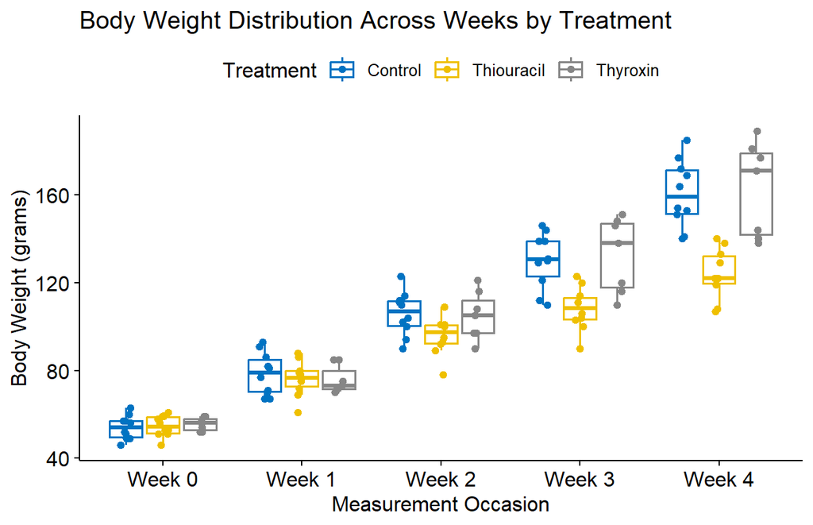

```r
# Boxplot across time points by treatment group
ggboxplot(
  rats,
  x = "time",
  y = "y",
  color = "trt",
  palette = "jco",
  add = "jitter"
) +
  labs(
    title = "Body Weight Distribution Across Weeks by Treatment",
    x = "Measurement Occasion",
    y = "Body Weight (grams)",
    color = "Treatment"
  )
```

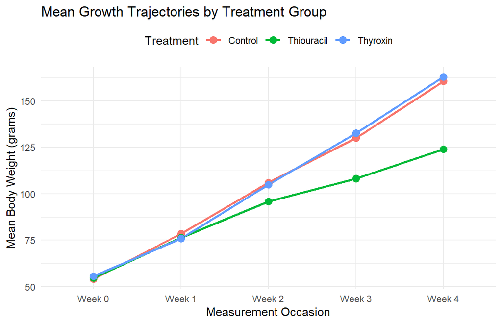

```r
# Interaction plot of mean body weights over time
rats %>%
  group_by(trt, time) %>%
  summarise(mean_weight = mean(y), .groups = "drop") %>%
  ggplot(aes(x = time, y = mean_weight, color = trt, group = trt)) +
  geom_line(linewidth = 1) +
  geom_point(size = 3) +
  labs(
    title = "Mean Growth Trajectories by Treatment Group",
    x = "Measurement Occasion",
    y = "Mean Body Weight (grams)",
    color = "Treatment"
  ) +
  theme_minimal() +
  theme(legend.position = "top")
```

## 3. Assumption Checks

```r
# Shapiro-Wilk test per Treatment x Time combination
rats %>%
  group_by(trt, time) %>%
  shapiro_test(y)
```

```
## # A tibble: 15 × 5
##    time   trt        variable statistic      p
##    <fct>  <fct>      <chr>        <dbl>  <dbl>
##  1 Week 0 Control    y            0.960 0.791
##  2 Week 1 Control    y            0.921 0.363
##  3 Week 2 Control    y            0.978 0.951
##  4 Week 3 Control    y            0.928 0.426
##  5 Week 4 Control    y            0.954 0.715
##  6 Week 0 Thiouracil y            0.946 0.617
##  7 Week 1 Thiouracil y            0.971 0.904
##  8 Week 2 Thiouracil y            0.941 0.562
##  9 Week 3 Thiouracil y            0.978 0.955
## 10 Week 4 Thiouracil y            0.936 0.507
## 11 Week 0 Thyroxin   y            0.888 0.264
## 12 Week 1 Thyroxin   y            0.789 0.0318
## 13 Week 2 Thyroxin   y            0.960 0.815
## 14 Week 3 Thyroxin   y            0.876 0.208
## 15 Week 4 Thyroxin   y            0.860 0.152
```

```r
# Identify univariate outliers per Treatment x Time cell (mild and extreme)
rats %>%
  group_by(trt, time) %>%
  identify_outliers(y)
```

```
## # A tibble: 2 × 6
##   time   trt        id        y is.outlier is.extreme
##   <fct>  <fct>      <fct> <int> <lgl>      <lgl>
## 1 Week 1 Thiouracil 19       61 TRUE       FALSE
## 2 Week 2 Thiouracil 19       78 TRUE       FALSE
```

```r
# Conduct Levene's test at each measurement occasion
rats %>%
  group_by(time) %>%
  levene_test(y ~ trt)
```

```
## # A tibble: 5 × 5
##   time     df1   df2 statistic     p
##   <fct>  <int> <int>     <dbl> <dbl>
## 1 Week 0     2    24     2.06  0.149
## 2 Week 1     2    24     1.18  0.326
## 3 Week 2     2    24     0.405 0.672
## 4 Week 3     2    24     1.67  0.210
## 5 Week 4     2    24     2.28  0.124
```

```r
# Reshape data to wide format for Box's M test
rats_wide <- rats %>%
  pivot_wider(
    id_cols = c(id, trt),
    names_from = time,
    values_from = y,
    names_prefix = "time_"
  )

# Perform Box's M test (evaluate at alpha = 0.001)
box_m(
  rats_wide %>% select(starts_with("time_")),
  rats_wide$trt
)
```

```
## # A tibble: 1 × 4
##   statistic p.value parameter method
##       <dbl>   <dbl>     <dbl> <chr>
## 1      22.4   0.839        30 Box's M-test for Homogeneity of Covariance Matric…
```

## 4. Mixed-Design Repeated Measures ANOVA

```r
# Fit mixed ANOVA
res.aov <- anova_test(
  data = rats,
  dv = y,
  wid = id,
  between = trt,
  within = time
)

# Display complete ANOVA and Sphericity output
res.aov
```

```
## ANOVA Table (type III tests)
##
## $ANOVA
##     Effect DFn DFd       F        p p<.05   ges
## 1      trt   2  24   7.884 2.00e-03     * 0.307
## 2     time   4  96 745.920 2.38e-71     * 0.910
## 3 trt:time   8  96  16.586 3.42e-15     * 0.310
##
## $`Mauchly's Test for Sphericity`
##     Effect     W        p p<.05
## 1     time 0.011 1.41e-17     *
## 2 trt:time 0.011 1.41e-17     *
##
## $`Sphericity Corrections`
##     Effect   GGe      DF[GG]    p[GG] p[GG]<.05   HFe      DF[HF]    p[HF]
## 1     time 0.342 1.37, 32.82 6.00e-26         * 0.356 1.42, 34.13 6.80e-27
## 2 trt:time 0.342 2.73, 32.82 1.73e-06         * 0.356 2.84, 34.13 1.13e-06
##   p[HF]<.05
## 1         *
## 2         *
```

```r
# Extract formatted ANOVA table
get_anova_table(res.aov)
```

```
## ANOVA Table (type III tests)
##
##     Effect  DFn   DFd       F        p p<.05   ges
## 1      trt 2.00 24.00   7.884 2.00e-03     * 0.307
## 2     time 1.37 32.82 745.920 6.00e-26     * 0.910
## 3 trt:time 2.73 32.82  16.586 1.73e-06     * 0.310
```

## 5. Simple Main Effects and Post-Hoc Comparisons

```r
# One-way ANOVA per time point
rats %>%
  group_by(time) %>%
  anova_test(dv = y, wid = id, between = trt) %>%
  get_anova_table() %>%
  knitr::kable(digits = 3)
```

| time | Effect | DFn | DFd | F | p | p<.05 | ges |
| --- | --- | --- | --- | --- | --- | --- | --- |
| Week 0 | trt | 2 | 24 | 0.236 | 0.792 |  | 0.019 |
| Week 1 | trt | 2 | 24 | 0.266 | 0.769 |  | 0.022 |
| Week 2 | trt | 2 | 24 | 3.173 | 0.060 |  | 0.209 |
| Week 3 | trt | 2 | 24 | 10.041 | 0.001 | * | 0.456 |
| Week 4 | trt | 2 | 24 | 17.798 | 0.000 | * | 0.597 |

```r
# Tukey HSD pairwise comparisons per week (all 15 rows across 5 weeks x 3 pairs)
rats %>%
  group_by(time) %>%
  tukey_hsd(y ~ trt) %>%
  select(time, group1, group2, estimate, conf.low, conf.high, p.adj, p.adj.signif) %>%
  knitr::kable(digits = 3)
```

| time | group1 | group2 | estimate | conf.low | conf.high | p.adj | p.adj.signif |
| --- | --- | --- | --- | --- | --- | --- | --- |
| Week 0 | Control | Thiouracil | 0.700 | -4.488 | 5.888 | 0.939 | ns |
| Week 0 | Control | Thyroxin | 1.571 | -4.145 | 7.288 | 0.774 | ns |
| Week 0 | Thiouracil | Thyroxin | 0.871 | -4.845 | 6.588 | 0.923 | ns |
| Week 1 | Control | Thiouracil | -2.200 | -11.459 | 7.059 | 0.825 | ns |
| Week 1 | Control | Thyroxin | -2.643 | -12.845 | 7.560 | 0.796 | ns |
| Week 1 | Thiouracil | Thyroxin | -0.443 | -10.645 | 9.760 | 0.994 | ns |
| Week 2 | Control | Thiouracil | -10.200 | -21.072 | 0.672 | 0.069 | ns |
| Week 2 | Control | Thyroxin | -1.143 | -13.123 | 10.838 | 0.969 | ns |
| Week 2 | Thiouracil | Thyroxin | 9.057 | -2.923 | 21.038 | 0.164 | ns |
| Week 3 | Control | Thiouracil | -21.900 | -36.329 | -7.471 | 0.002 | ** |
| Week 3 | Control | Thyroxin | 2.614 | -13.285 | 18.514 | 0.912 | ns |
| Week 3 | Thiouracil | Thyroxin | 24.514 | 8.615 | 40.414 | 0.002 | ** |
| Week 4 | Control | Thiouracil | -36.600 | -54.249 | -18.951 | 0.000 | **** |
| Week 4 | Control | Thyroxin | 2.257 | -17.191 | 21.705 | 0.955 | ns |
| Week 4 | Thiouracil | Thyroxin | 38.857 | 19.409 | 58.305 | 0.000 | *** |

```r
# Repeated measures ANOVA per treatment group
rats %>%
  group_by(trt) %>%
  anova_test(dv = y, wid = id, within = time) %>%
  get_anova_table()
```

```
## # A tibble: 3 × 8
##   trt        Effect   DFn   DFd     F        p `p<.05`   ges
##   <fct>      <chr>  <dbl> <dbl> <dbl>    <dbl> <chr>   <dbl>
## 1 Control    time    1.32 11.9   399. 5.53e-11 *       0.928
## 2 Thiouracil time    1.77 15.9   225. 4.09e-12 *       0.896
## 3 Thyroxin   time    1.15  6.91  161. 3.83e- 6 *       0.903
```

```r
# Paired t-tests between weeks with Holm correction (adjusted within each treatment group)
rats %>%
  group_by(trt) %>%
  pairwise_t_test(
    y ~ time,
    paired = TRUE,
    p.adjust.method = "holm"
  ) %>%
  knitr::kable(digits = 3)
```

| trt | .y. | group1 | group2 | n1 | n2 | statistic | df | p | p.adj | p.adj.signif |
| --- | --- | --- | --- | --- | --- | --- | --- | --- | --- | --- |
| Control | y | Week 0 | Week 1 | 10 | 10 | -16.020 | 9 | 0 | 0 | **** |
| Control | y | Week 0 | Week 2 | 10 | 10 | -23.518 | 9 | 0 | 0 | **** |
| Control | y | Week 0 | Week 3 | 10 | 10 | -20.973 | 9 | 0 | 0 | **** |
| Control | y | Week 0 | Week 4 | 10 | 10 | -23.371 | 9 | 0 | 0 | **** |
| Control | y | Week 1 | Week 2 | 10 | 10 | -18.333 | 9 | 0 | 0 | **** |
| Control | y | Week 1 | Week 3 | 10 | 10 | -15.779 | 9 | 0 | 0 | **** |
| Control | y | Week 1 | Week 4 | 10 | 10 | -19.020 | 9 | 0 | 0 | **** |
| Control | y | Week 2 | Week 3 | 10 | 10 | -12.967 | 9 | 0 | 0 | **** |
| Control | y | Week 2 | Week 4 | 10 | 10 | -18.263 | 9 | 0 | 0 | **** |
| Control | y | Week 3 | Week 4 | 10 | 10 | -17.997 | 9 | 0 | 0 | **** |
| Thiouracil | y | Week 0 | Week 1 | 10 | 10 | -12.699 | 9 | 0 | 0 | **** |
| Thiouracil | y | Week 0 | Week 2 | 10 | 10 | -22.042 | 9 | 0 | 0 | **** |
| Thiouracil | y | Week 0 | Week 3 | 10 | 10 | -21.791 | 9 | 0 | 0 | **** |
| Thiouracil | y | Week 0 | Week 4 | 10 | 10 | -20.116 | 9 | 0 | 0 | **** |
| Thiouracil | y | Week 1 | Week 2 | 10 | 10 | -14.602 | 9 | 0 | 0 | **** |
| Thiouracil | y | Week 1 | Week 3 | 10 | 10 | -11.935 | 9 | 0 | 0 | **** |
| Thiouracil | y | Week 1 | Week 4 | 10 | 10 | -12.225 | 9 | 0 | 0 | **** |
| Thiouracil | y | Week 2 | Week 3 | 10 | 10 | -7.262 | 9 | 0 | 0 | **** |
| Thiouracil | y | Week 2 | Week 4 | 10 | 10 | -9.255 | 9 | 0 | 0 | **** |
| Thiouracil | y | Week 3 | Week 4 | 10 | 10 | -7.317 | 9 | 0 | 0 | **** |
| Thyroxin | y | Week 0 | Week 1 | 7 | 7 | -12.454 | 6 | 0 | 0 | **** |
| Thyroxin | y | Week 0 | Week 2 | 7 | 7 | -13.961 | 6 | 0 | 0 | **** |
| Thyroxin | y | Week 0 | Week 3 | 7 | 7 | -13.107 | 6 | 0 | 0 | **** |
| Thyroxin | y | Week 0 | Week 4 | 7 | 7 | -14.031 | 6 | 0 | 0 | **** |
| Thyroxin | y | Week 1 | Week 2 | 7 | 7 | -11.983 | 6 | 0 | 0 | **** |
| Thyroxin | y | Week 1 | Week 3 | 7 | 7 | -10.938 | 6 | 0 | 0 | **** |
| Thyroxin | y | Week 1 | Week 4 | 7 | 7 | -12.435 | 6 | 0 | 0 | **** |
| Thyroxin | y | Week 2 | Week 3 | 7 | 7 | -8.560 | 6 | 0 | 0 | *** |
| Thyroxin | y | Week 2 | Week 4 | 7 | 7 | -11.589 | 6 | 0 | 0 | **** |
| Thyroxin | y | Week 3 | Week 4 | 7 | 7 | -14.773 | 6 | 0 | 0 | **** |

## 6. APA Results Summary

A two-way mixed-design repeated measures ANOVA was conducted to examine the effects of treatment group (Control, Thiouracil, Thyroxin; between-subjects) and measurement occasion (Week 0 to Week 4; within-subjects) on rat body weight ($N = 27$ rats across $135$ observations). Because Mauchly’s test indicated violations of sphericity ($W = 0.011$, $p < .001$), Greenhouse–Geisser corrected degrees of freedom are reported for within-subjects effects.

- **Treatment $\times$ Time Interaction:** $F(2.73, 32.82) = 16.59$, $p < .001$, $\eta_G^2 = .31$
- **Main Effect of Treatment:** $F(2.00, 24.00) = 7.88$, $p = .002$, $\eta_G^2 = .31$
- **Main Effect of Time:** $F(1.37, 32.82) = 745.92$, $p < .001$, $\eta_G^2 = .91$

Follow-up simple main effects showed no significant differences in body weight among treatment groups at Week 0, $F(2, 24) = 0.24$, $p = .792$, $\eta_G^2 = .02$; Week 1, $F(2, 24) = 0.27$, $p = .769$, $\eta_G^2 = .02$; or Week 2, $F(2, 24) = 3.17$, $p = .060$, $\eta_G^2 = .21$. Significant group differences emerged by Week 3, $F(2, 24) = 10.04$, $p = .001$, $\eta_G^2 = .46$, and persisted through Week 4, $F(2, 24) = 17.80$, $p < .001$, $\eta_G^2 = .60$, where Tukey HSD post-hoc tests indicated that the Thiouracil group had significantly lower mean body weight than both the Control and Thyroxin groups ($p_{\text{adj}} \le .002$ at Week 3; $p_{\text{adj}} < .001$ at Week 4), while Control and Thyroxin did not differ significantly ($p_{\text{adj}} \ge .912$). Within each treatment group, body weight increased significantly over time for Control, $F(1.32, 11.90) = 399.00$, $p < .001$, $\eta_G^2 = .93$, Thiouracil, $F(1.77, 15.90) = 225.00$, $p < .001$, $\eta_G^2 = .90$, and Thyroxin, $F(1.15, 6.91) = 161.00$, $p < .001$, $\eta_G^2 = .90$.